# PW7 : Principal Component Analysis

Sandrine NEANG

05/12/2022

Exemple 1 : Decathlon Data  
Question 1 : Install packages FactoMineR and factoextra

```r
library(FactoMineR)
library(factoextra)
```

**Load the demo data sets decathlon2 from the factoextra package using the data operator and show its first lines using head**

```r
data(decathlon2)
head(decathlon2)
```

```
##           X100m Long.jump Shot.put High.jump X400m X110m.hurdle Discus
## SEBRLE    11.04      7.58    14.83      2.07 49.81        14.69  43.75
## CLAY      10.76      7.40    14.26      1.86 49.37        14.05  50.72
## BERNARD   11.02      7.23    14.25      1.92 48.93        14.99  40.87
## YURKOV    11.34      7.09    15.19      2.10 50.42        15.31  46.26
## ZSIVOCZKY 11.13      7.30    13.48      2.01 48.62        14.17  45.67
## McMULLEN  10.83      7.31    13.76      2.13 49.91        14.38  44.41
##           Pole.vault Javeline X1500m Rank Points Competition
## SEBRLE          5.02    63.19  291.7    1   8217    Decastar
## CLAY            4.92    60.15  301.5    2   8122    Decastar
## BERNARD         5.32    62.77  280.1    4   8067    Decastar
## YURKOV          4.72    63.44  276.4    5   8036    Decastar
## ZSIVOCZKY       4.42    55.37  268.0    7   8004    Decastar
## McMULLEN        4.42    56.37  285.1    8   7995    Decastar
```

**Question 3 : Use str function to describe your data**

```r
str(decathlon2)
```

```
## 'data.frame':    27 obs. of  13 variables:
##  $ X100m       : num  11 10.8 11 11.3 11.1 ...
##  $ Long.jump   : num  7.58 7.4 7.23 7.09 7.3 7.31 6.81 7.56 6.97 7.27 ...
##  $ Shot.put    : num  14.8 14.3 14.2 15.2 13.5 ...
##  $ High.jump   : num  2.07 1.86 1.92 2.1 2.01 2.13 1.95 1.86 1.95 1.98 ...
##  $ X400m       : num  49.8 49.4 48.9 50.4 48.6 ...
##  $ X110m.hurdle: num  14.7 14.1 15 15.3 14.2 ...
##  $ Discus      : num  43.8 50.7 40.9 46.3 45.7 ...
##  $ Pole.vault  : num  5.02 4.92 5.32 4.72 4.42 4.42 4.92 4.82 4.72 4.62 ...
##  $ Javeline    : num  63.2 60.1 62.8 63.4 55.4 ...
##  $ X1500m      : num  292 302 280 276 268 ...
##  $ Rank        : int  1 2 4 5 7 8 9 10 11 12 ...
##  $ Points      : int  8217 8122 8067 8036 8004 7995 7802 7733 7708 7651 ...
##  $ Competition : Factor w/ 2 levels "Decastar","OlympicG": 1 1 1 1 1 1 1 1 1 1 ...
```

**Question 4 : Extract only active individuals and variables**

```r
decathlon3 <-decathlon2[1:23,1:10]
head(decathlon3)
```

```
##           X100m Long.jump Shot.put High.jump X400m X110m.hurdle Discus
## SEBRLE    11.04      7.58    14.83      2.07 49.81        14.69  43.75
## CLAY      10.76      7.40    14.26      1.86 49.37        14.05  50.72
## BERNARD   11.02      7.23    14.25      1.92 48.93        14.99  40.87
## YURKOV    11.34      7.09    15.19      2.10 50.42        15.31  46.26
## ZSIVOCZKY 11.13      7.30    13.48      2.01 48.62        14.17  45.67
## McMULLEN  10.83      7.31    13.76      2.13 49.91        14.38  44.41
##           Pole.vault Javeline X1500m
## SEBRLE          5.02    63.19  291.7
## CLAY            4.92    60.15  301.5
## BERNARD         5.32    62.77  280.1
## YURKOV          4.72    63.44  276.4
## ZSIVOCZKY       4.42    55.37  268.0
## McMULLEN        4.42    56.37  285.1
```

**Question 5 : Use the function PCA() from the FactoMineR package and construct a PCA on a scaled version of the decathlon2 data**

```r
data<-PCA(scale(decathlon3),graph = FALSE)
```

**Question 6 : Show the output list of the function PCA()**

```r
print(data)
```

```
## **Results for the Principal Component Analysis (PCA)**
## The analysis was performed on 23 individuals, described by 10 variables
## *The results are available in the following objects:
##
##    name               description
## 1  "$eig"             "eigenvalues"
## 2  "$var"             "results for the variables"
## 3  "$var$coord"       "coord. for the variables"
## 4  "$var$cor"         "correlations variables - dimensions"
## 5  "$var$cos2"        "cos2 for the variables"
## 6  "$var$contrib"     "contributions of the variables"
## 7  "$ind"             "results for the individuals"
## 8  "$ind$coord"       "coord. for the individuals"
## 9  "$ind$cos2"        "cos2 for the individuals"
## 10 "$ind$contrib"     "contributions of the individuals"
## 11 "$call"            "summary statistics"
## 12 "$call$centre"     "mean of the variables"
## 13 "$call$ecart.type" "standard error of the variables"
## 14 "$call$row.w"      "weights for the individuals"
## 15 "$call$col.w"      "weights for the variables"
```

**Question 7 : Examine the eigenvalues to determine the number of principal components to be considered using the function get_eigenvalue() from the factoextra packages**

```r
get_eigenvalue(data)
```

```
##        eigenvalue variance.percent cumulative.variance.percent
## Dim.1   4.1242133        41.242133                    41.24213
## Dim.2   1.8385309        18.385309                    59.62744
## Dim.3   1.2391403        12.391403                    72.01885
## Dim.4   0.8194402         8.194402                    80.21325
## Dim.5   0.7015528         7.015528                    87.22878
## Dim.6   0.4228828         4.228828                    91.45760
## Dim.7   0.3025817         3.025817                    94.48342
## Dim.8   0.2744700         2.744700                    97.22812
## Dim.9   0.1552169         1.552169                    98.78029
## Dim.10  0.1219710         1.219710                   100.00000
```

**Question 8 : Show the scree plot using the function fviz_eig() and discuss how many principal components are enough**

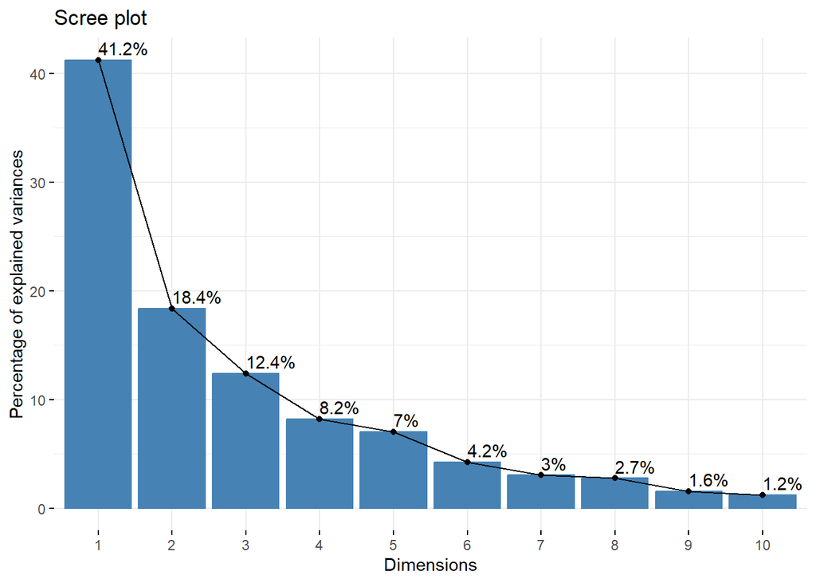

```r
fviz_eig(data,addlabels = TRUE)
```

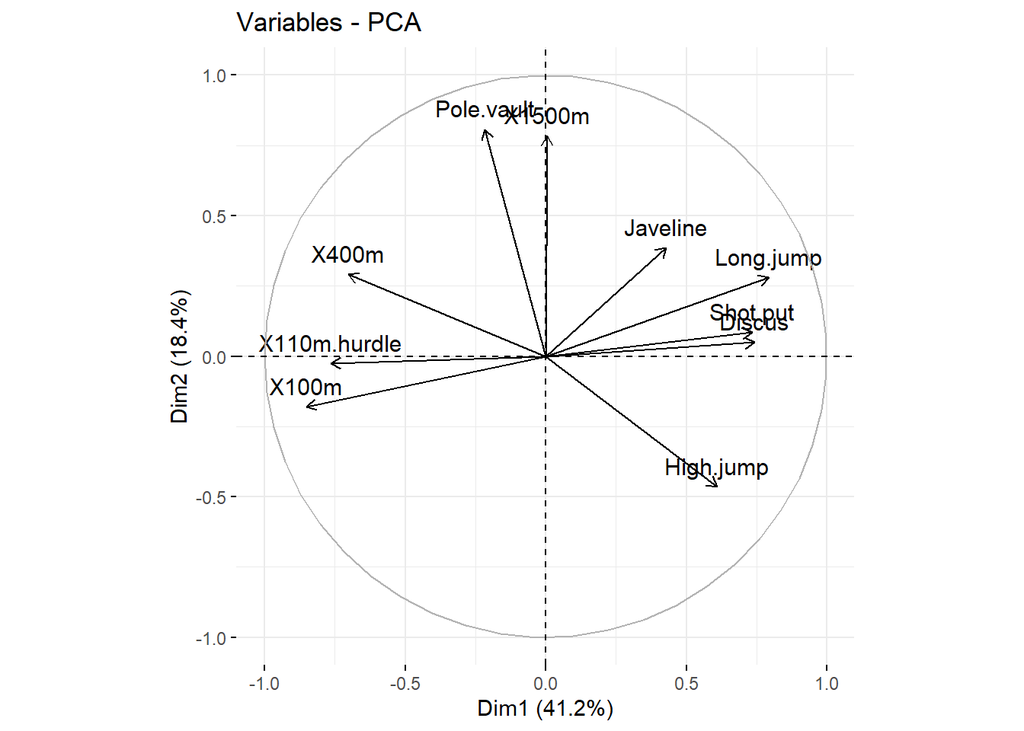

```r
fviz_pca_var(data)
```

**Question 10 : Print the quality of representation of the variables and plot them**

```r
get_pca_var(data)$cos2
```

```
##                     Dim.1        Dim.2       Dim.3        Dim.4      Dim.5
## X100m        7.235641e-01 0.0321836641 0.090936280 0.0011271597 0.03780845
## Long.jump    6.307229e-01 0.0788806285 0.036307981 0.0133147506 0.05436203
## Shot.put     5.386279e-01 0.0072938636 0.267907488 0.0165041211 0.06190783
## High.jump    3.722025e-01 0.2164242070 0.108956221 0.0208947375 0.16216747
## X400m        4.922473e-01 0.0842034209 0.080390914 0.1856106269 0.01079698
## X110m.hurdle 5.838873e-01 0.0006121077 0.201499837 0.0002854712 0.05027463
## Discus       5.523596e-01 0.0024662013 0.031161138 0.1560322304 0.16665918
## Pole.vault   4.720540e-02 0.6519772763 0.008846856 0.1149106765 0.04914437
## Javeline     1.833781e-01 0.1490803723 0.364966189 0.1100478063 0.03912992
## X1500m       1.830545e-05 0.6154091638 0.048167378 0.2007126089 0.06930197
```

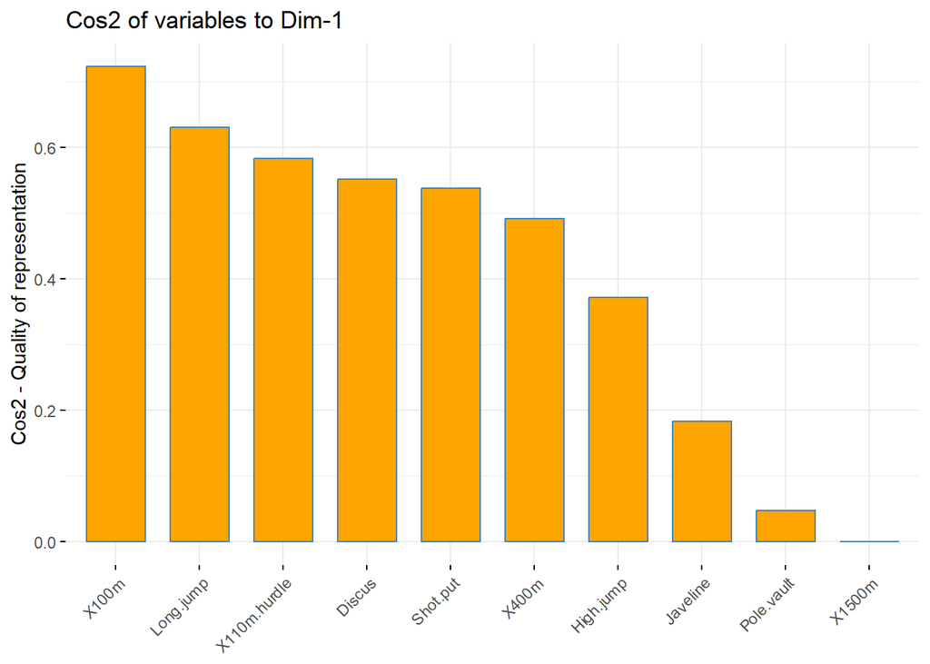

```r
fviz_cos2(data,choice = 'var',fill='orange')
```

**Question 11 : Color variables by their cos2 values using the argument col.var**

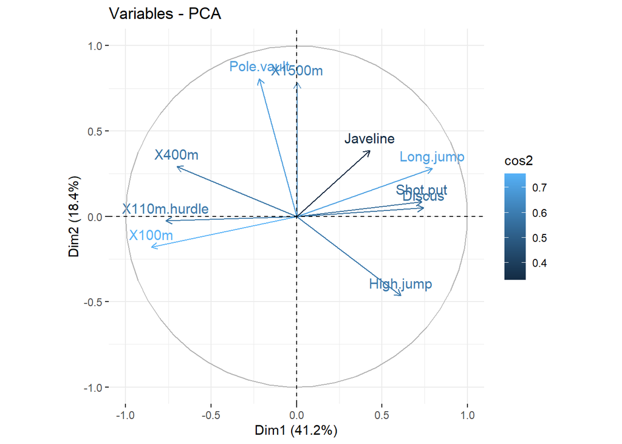

```r
fviz_pca_var(data,col.var = 'cos2',)
```

**Question 12 : Apply the function dimdesc() from FactoMineR, to show a dimension description and identify the most significantly associated variables with first principal components**

```r
dimdesc(data,axes =c(1,2))$Dim.1
```

```
##
## Link between the variable and the continuous variables (R-square)
## =================================================================================
##              correlation      p.value
## Long.jump      0.7941806 6.059893e-06
## Discus         0.7432090 4.842563e-05
## Shot.put       0.7339127 6.723102e-05
## High.jump      0.6100840 1.993677e-03
## Javeline       0.4282266 4.149192e-02
## X400m         -0.7016034 1.910387e-04
## X110m.hurdle  -0.7641252 2.195812e-05
## X100m         -0.8506257 2.727129e-07
```

```r
dimdesc(data,axes =c(1,2))$Dim.2
```

```
##
## Link between the variable and the continuous variables (R-square)
## =================================================================================
##            correlation      p.value
## Pole.vault   0.8074511 3.205016e-06
## X1500m       0.7844802 9.384747e-06
## High.jump   -0.4652142 2.529390e-02
```

**Question 13 : Extract the results for individuals using the function get_pca_ind()**

```r
get_pca_ind(data)
```

```
## Principal Component Analysis Results for individuals
##  ===================================================
##   Name       Description
## 1 "$coord"   "Coordinates for the individuals"
## 2 "$cos2"    "Cos2 for the individuals"
## 3 "$contrib" "contributions of the individuals"
```

**Question 14 : Produce the graph of individuals using fviz_pca_ind() and color individuals by their cos2 values**

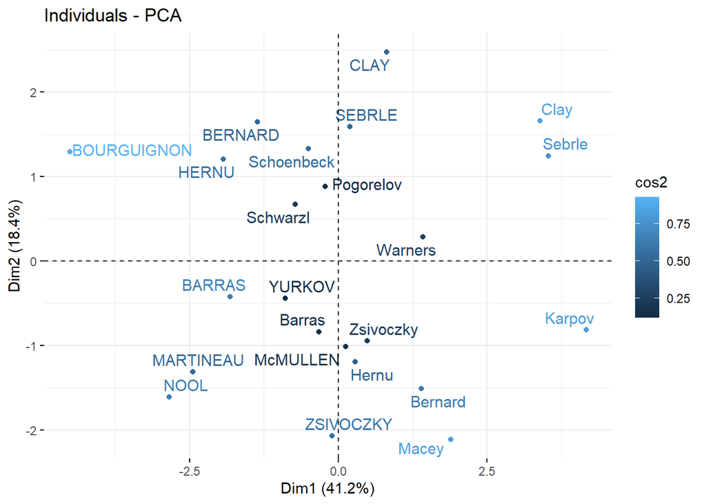

```r
fviz_pca_ind(data, col.ind="cos2",repel=TRUE)
```

**Question 15 : Change the point size according the cos2 of the corresponding individuals**

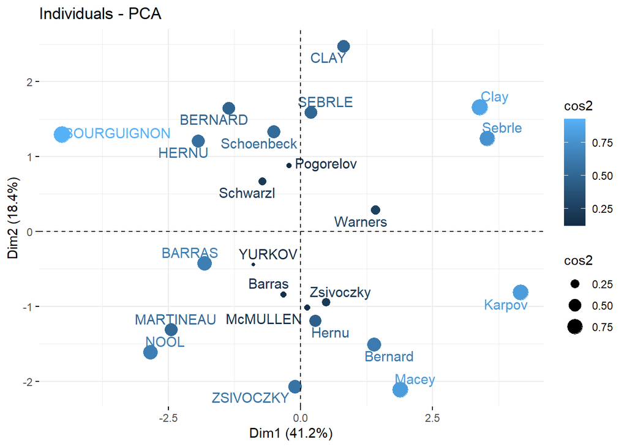

```r
fviz_pca_ind(data, col.ind="cos2",pointsize="cos2",repel=TRUE)
```

**Question 16 : Specify supplementary individuals and variables, the function PCA()**

```r
data2<-PCA(decathlon2,ind.sup = 24:27,quanti.sup = 11:12,quali.sup = 13,graph=FALSE)
```

**Question 17 : Predict results (coordinates, correlation and cos2) for the supplementary quantitative variable**

```r
data2$quanti.sup
```

```
## $coord
##             Dim.1       Dim.2      Dim.3       Dim.4       Dim.5
## Rank   -0.7014777 -0.24519443 -0.1834294  0.05575186 -0.07382647
## Points  0.9637075  0.07768262  0.1580225 -0.16623092 -0.03114711
##
## $cor
##             Dim.1       Dim.2      Dim.3       Dim.4       Dim.5
## Rank   -0.7014777 -0.24519443 -0.1834294  0.05575186 -0.07382647
## Points  0.9637075  0.07768262  0.1580225 -0.16623092 -0.03114711
##
## $cos2
##            Dim.1       Dim.2      Dim.3      Dim.4        Dim.5
## Rank   0.4920710 0.060120310 0.03364635 0.00310827 0.0054503477
## Points 0.9287322 0.006034589 0.02497110 0.02763272 0.0009701427
```

**Question 18 : Predict results for the supplementary individuals (ind.sup) and visualize all individuals (active and supplementary ones)**

```r
data2$ind.sup
```

```
## $coord
##              Dim.1       Dim.2      Dim.3      Dim.4       Dim.5
## KARPOV   0.7947206  0.77951227 -1.6330203  1.7242283 -0.75070396
## WARNERS -0.3864645 -0.12159237 -1.7387332 -0.7063341 -0.03230011
## Nool    -0.5591306  1.97748871 -0.4830358 -2.2784526 -0.25461493
## Drews   -1.1092038  0.01741477 -3.0488182 -1.5343468 -0.32642192
##
## $cos2
##              Dim.1        Dim.2      Dim.3      Dim.4        Dim.5
## KARPOV  0.05104677 4.911173e-02 0.21553730 0.24028620 0.0455487744
## WARNERS 0.02422707 2.398250e-03 0.49039677 0.08092862 0.0001692349
## Nool    0.02897149 3.623868e-01 0.02162236 0.48108780 0.0060077529
## Drews   0.09207094 2.269527e-05 0.69560547 0.17617609 0.0079736753
##
## $dist
##   KARPOV  WARNERS     Nool    Drews
## 3.517470 2.482899 3.284943 3.655527
```

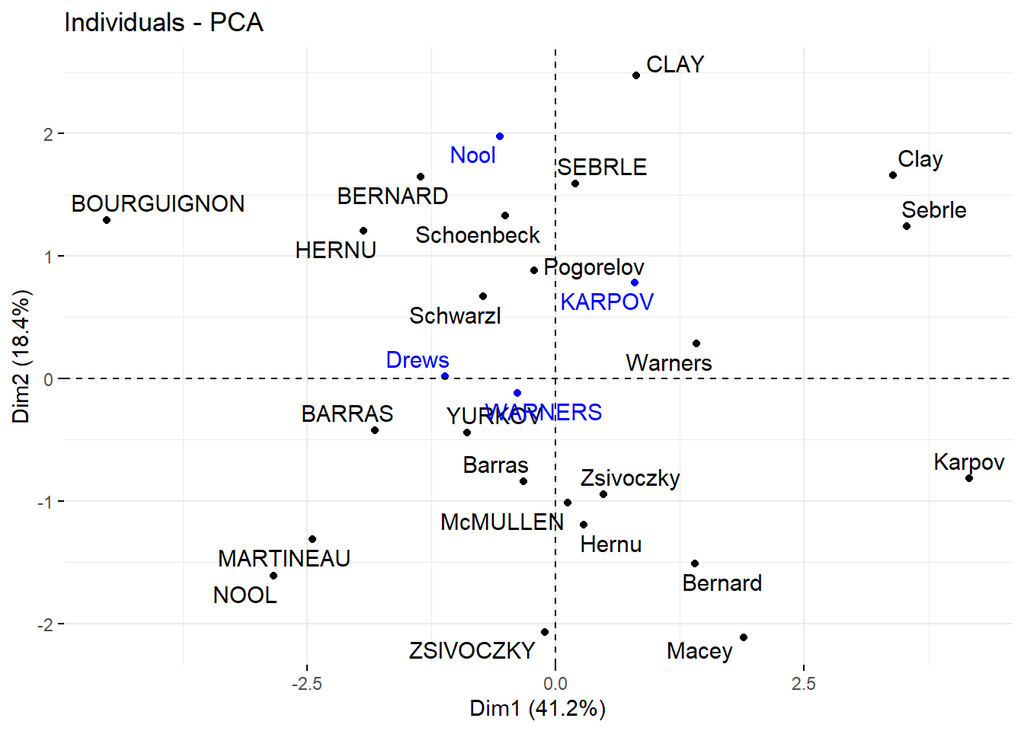

```r
fviz_pca_ind(data2,repel=TRUE)
```

**Question 19 : Color individuals by the supplementary qualitative variable (columns 13 corresponding to the type of competitions), using the argument habillage to specify the index of the supplementary qualitative variable**

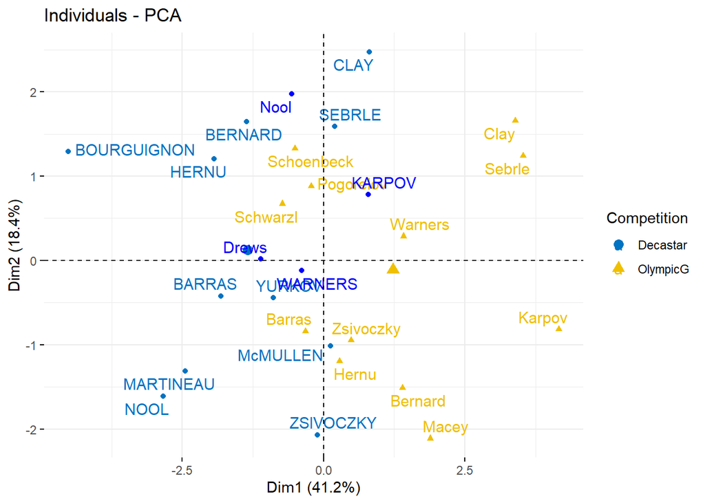

```r
fviz_pca_ind(data2, habillage = 13,palette = "jco", repel = TRUE)
```

**Question 20 : Interpret and analyze the obtained results**

The first component positively correlated to “strength” competations and negatively to speed ones The second one is linked to endurance and pole vault. The right side is for better points and smaller rank, i.,e. best players. The opposite profiles at at the left.

When looking at the points representing Decastar and Olympic Games, we notice that this last one has higher coordinates on the first axis than the first one. This shows an evolution in the performances of the athletes. All the athletes who participated to the two competitions have then slightly better results for the Olympic Games.

However, there is no difference between the points Decastar and Olympic Games for the second axis. This means that the athletes have improved their performance but did not change profile.

We can see that the points which represent the same individual are in the same direction.

```r
iris = read.csv("C:/Users/sandr/OneDrive/Documents/Scolarité/ESILV/M1 A4/S7/Machine Learning/TDs/Datas/iris.data")
```

**Question 2 : Compare the means and the quartiles of the 3 different flower classes for the 4 different features**

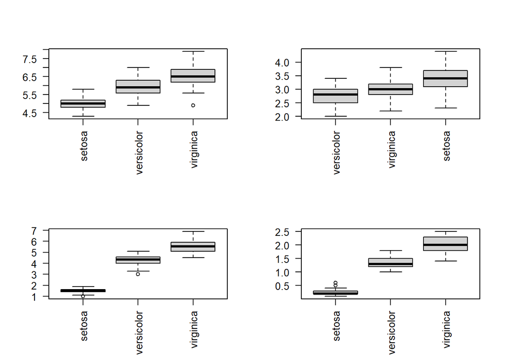

```r
par(mfrow = c(2, 2))

# Lower to higher
medians <- reorder(iris$class, iris$sepal_length, median)

boxplot(iris$sepal_length ~ medians, las = 2, xlab = "", ylab = "")

# Lower to higher
medians <- reorder(iris$class, iris$sepal_width, median)

boxplot(iris$sepal_width ~ medians, las = 2, xlab = "", ylab = "")

# Lower to higher
medians <- reorder(iris$class, iris$petal_length, median)

boxplot(iris$petal_length ~ medians, las = 2, xlab = "", ylab = "")

# Lower to higher
medians <- reorder(iris$class, iris$petal_width, median)

boxplot(iris$petal_width ~ medians, las = 2, xlab = "", ylab = "")
```

**Question 3 : To explore how the 3 different flower classes are distributed along the 4 different features, visualize them via histograms using the ggplot packages through the geom_histogram plot.**

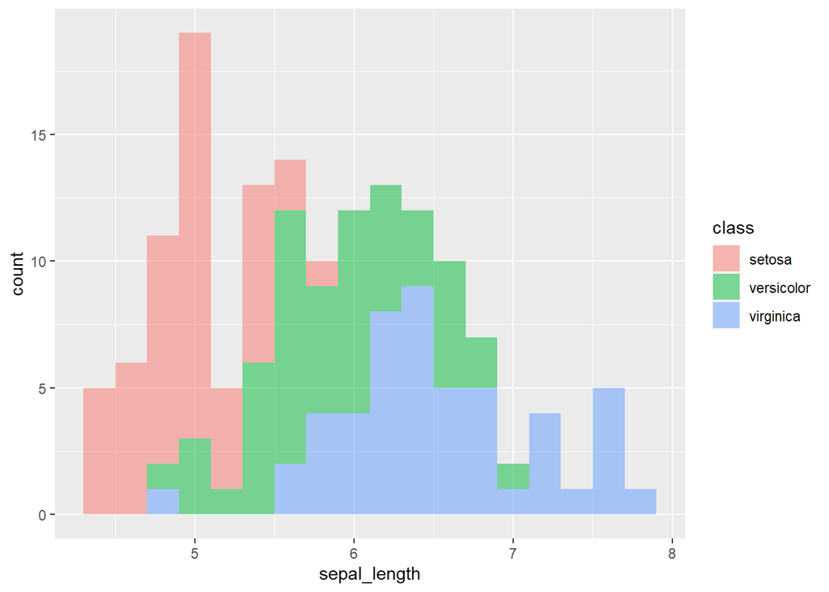

```r
library(ggplot2)

ggplot(iris, aes(x=sepal_length, fill=class)) +
  geom_histogram(binwidth=.2, alpha=.5) #histogram of sepal_length
```

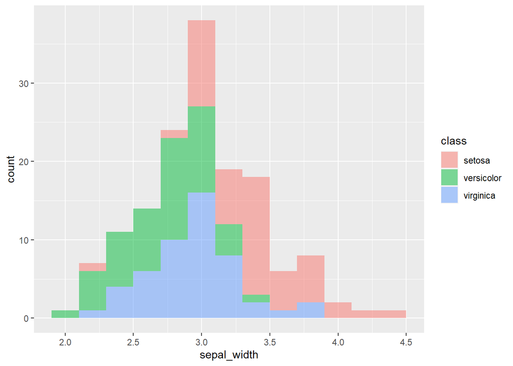

```r
# histogram of sepal_width
ggplot(iris, aes(x=sepal_width, fill=class)) +
  geom_histogram(binwidth=.2, alpha=.5)
```

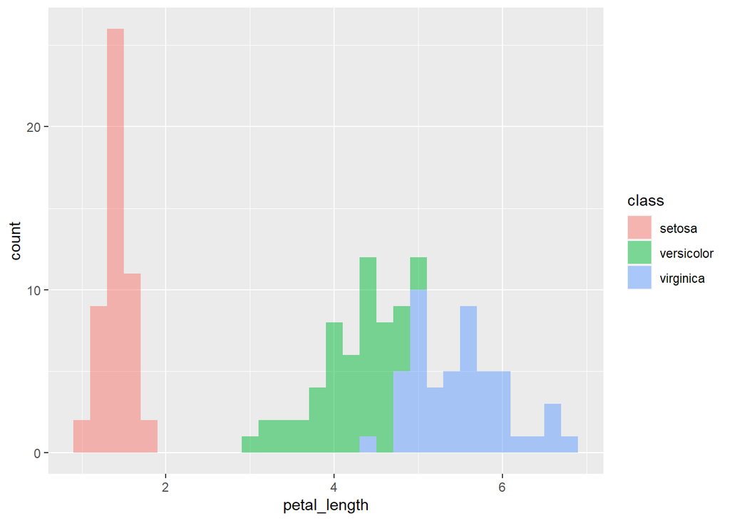

```r
# histogram of petal_length
ggplot(iris, aes(x=petal_length, fill=class)) +
  geom_histogram(binwidth=.2, alpha=.5)
```

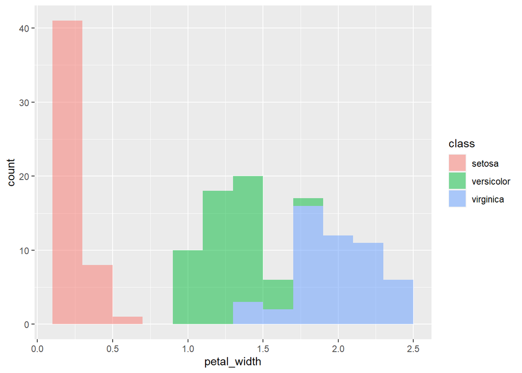

```r
# histogram of petal_width
ggplot(iris, aes(x=petal_width, fill=class)) +
  geom_histogram(binwidth=.2, alpha=.5)
```

```r
par(mfrow=c(2,2))
```

**Question 4 : Apply a PCA on the iris dataset using the princomp function and interpret the results**

```r
pcairis=princomp(iris[,-5], cor=T)
# numerical columns for PCA.

str(pcairis)  #internal structure of pcairis
```

```
## List of 7
##  $ sdev    : Named num [1:4] 1.706 0.96 0.384 0.144
##   ..- attr(*, "names")= chr [1:4] "Comp.1" "Comp.2" "Comp.3" "Comp.4"
##  $ loadings: 'loadings' num [1:4, 1:4] 0.522 -0.263 0.581 0.566 0.372 ...
##   ..- attr(*, "dimnames")=List of 2
##   .. ..$ : chr [1:4] "sepal_length" "sepal_width" "petal_length" "petal_width"
##   .. ..$ : chr [1:4] "Comp.1" "Comp.2" "Comp.3" "Comp.4"
##  $ center  : Named num [1:4] 5.84 3.05 3.76 1.2
##   ..- attr(*, "names")= chr [1:4] "sepal_length" "sepal_width" "petal_length" "petal_width"
##  $ scale   : Named num [1:4] 0.825 0.432 1.759 0.761
##   ..- attr(*, "names")= chr [1:4] "sepal_length" "sepal_width" "petal_length" "petal_width"
##  $ n.obs   : int 150
##  $ scores  : num [1:150, 1:4] -2.26 -2.09 -2.37 -2.3 -2.39 ...
##   ..- attr(*, "dimnames")=List of 2
##   .. ..$ : NULL
##   .. ..$ : chr [1:4] "Comp.1" "Comp.2" "Comp.3" "Comp.4"
##  $ call    : language princomp(x = iris[, -5], cor = T)
##  - attr(*, "class")= chr "princomp"
```

```r
summary(pcairis) # variance explained by the pcs
```

```
## Importance of components:
##                           Comp.1    Comp.2     Comp.3      Comp.4
## Standard deviation     1.7061120 0.9598025 0.38386622 0.143553848
## Proportion of Variance 0.7277045 0.2303052 0.03683832 0.005151927
## Cumulative Proportion  0.7277045 0.9580098 0.99484807 1.000000000
```

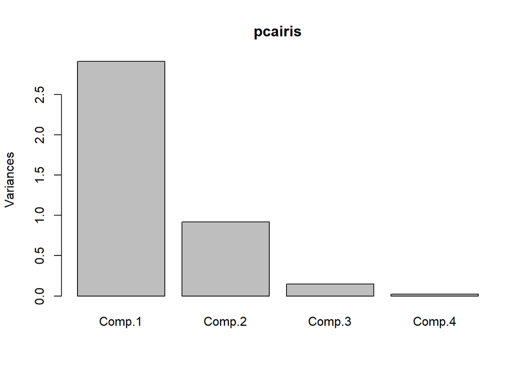

```r
plot(pcairis)  #plot the variance explained by each pc
```

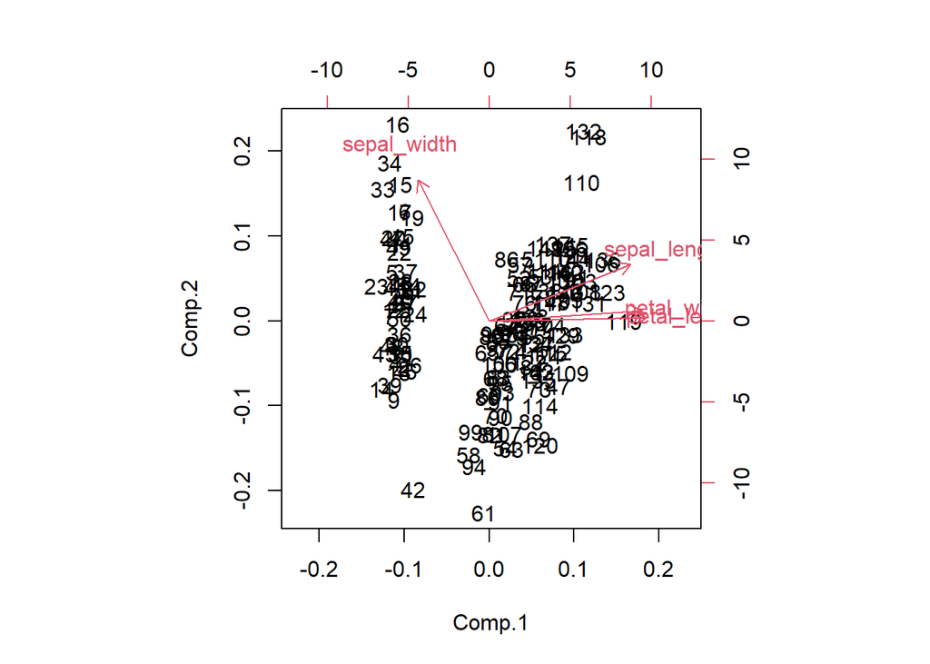

```r
biplot(pcairis)
```

**Question 5 : By using the factoextra packages, plot the scree plot, the graph of individuals, the graph of variables, the biplot graph and the contributions of the variables to the first 2 principal components.**

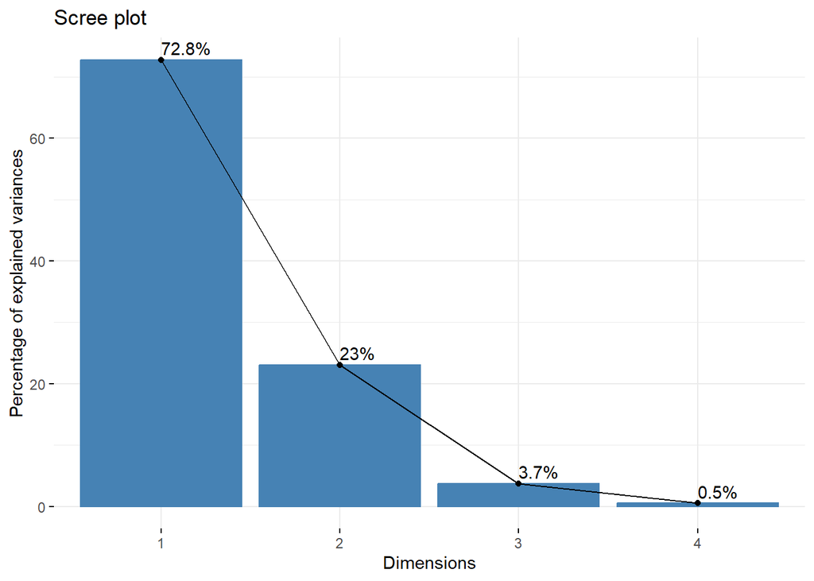

```r
pcairis=princomp(iris[,-5], cor=T)
#Scree plot
fviz_eig(pcairis,addlabels = TRUE)
```

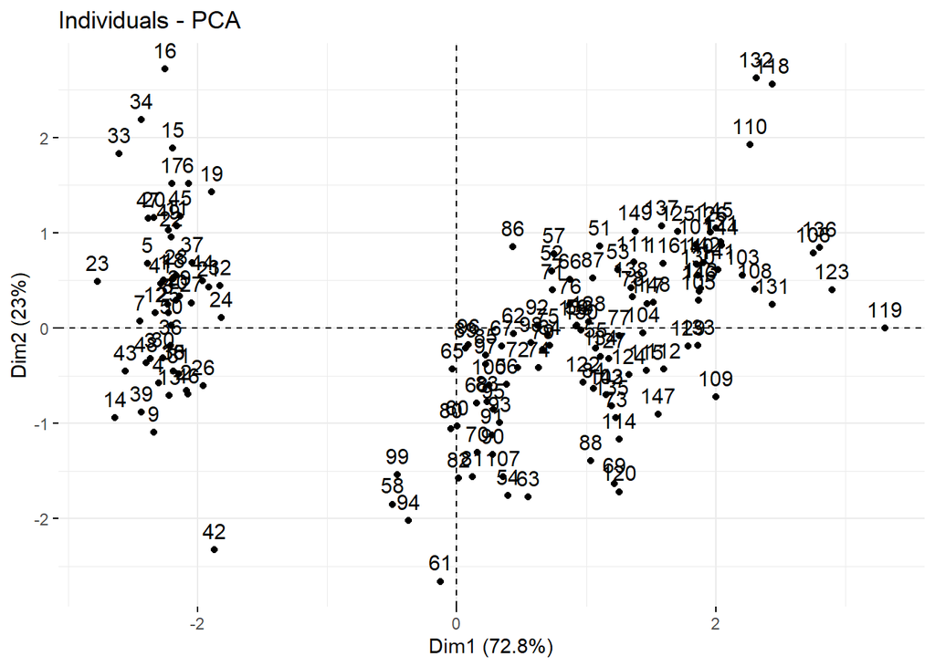

```r
#The graph of individuals
fviz_pca_ind(pcairis)
```